# Selection Sortst (Seleksi)

Algoritma sorting yang kedua adalah Selection Sort. Penjelasan algoritma ini dibagi menjadi dua bagian yaitu :

1. Algoritma Selection Sort
2. Code

#### Algoritma Selection Sort

Algoritma **selection sort** memiliki waktu komputasi yang lebih cepat dibandingkan dengan algoritma **bubble sort**. Hal ini dikarenakan terjadi **reduksi waktu pada saat proses pertukaran data**. Jika algoritma bubble sort, pada setiap iterasi,setiap dua data yang berdekatan akan dibandingkan, dan akan dilakukan pertukaran data jika syarat memenuhi. Maka pada algoritma selection sort tidak akan melakukan dua proses ini (perbandingan dan pertukaran) pada satu waktu, akan tetapi, pada algoritma selection sort, akan dicari data yang memenuhi syarat terlebih dahulu (perbandingan data), kemudian data yang terpilih ini ini akan diletakkan pada indeks data yang tepat. Oleh karena itu algoritma ini dinamakan selection (pemilihan data).

#### Berikut tahapan algoritma selection sort **(ascending order)**:

1. Algoritma ini dimulai dari indeks awal sampai dengan indeks akhir data
2. Cari data dengan nilai paling minimal (dari indeks awal sampai dengan indeks akhir) melalui proses perbandingan
3. Letakkan data minimal ini di indeks awal
4. Ulangi lagi proses pencarian data paling minimal (dari indeks awal+1 sampai dengan indeks akhir, karena indeks awal sudah terisi data yang tepat).
5. Letakkan data ini pada indeks awal+1
6. Ulangi lagi proses pencarian data paling minimal (dari indeks awal+2 sampai dengan akhir) dan letakkan data ini pada indeks awal+2, dst.

### Panduan Langkah demi Langkah

Sebelum kita mengimplementasikan algoritma Selection Sort dalam bahasa pemrograman, mari kita jalankan secara manual satu kali saja pada sebuah array pendek, hanya untuk mendapatkan gambaran dasarnya.

**Langkah 1**: Kita mulai dengan array yang belum diurutkan.

[ 7, 12, 9, 11, 3]

**Langkah 2**: Telusuri array, satu nilai per satu. Nilai mana yang terendah? 3, kan?

[ 7, 12, 9, 11, 3]

**Langkah 3**: Pindahkan nilai terendah, yaitu 3, ke bagian depan array.

[ 3, 7, 12, 9, 11]

**Langkah 4**: Periksa nilai-nilai lainnya, dimulai dari 7. 7 adalah nilai terendah, dan sudah berada di bagian depan array, jadi kita tidak perlu memindahkannya.

[ 3, 7, 12, 9, 11]

**Langkah 5**: Periksa sisa array: 12, 9, dan 11. 9 adalah nilai terendah.

[ 3, 7, 12, 9, 11]

**Langkah 6**: Pindahkan 9 ke depan.

[ 3, 7, 9, 12, 11]

**Langkah 7**: Melihat angka 12 dan 11, 11 adalah yang terendah.

[ 3, 7, 9, 12, 11]

**Langkah 8**: Pindahkan ke depan.

[ 3, 7, 9, 11, 12]

Akhirnya, array tersebut telah diurutkan.

Pengurutan Seleksi [3 ,7 ,9 ,11 ,12]

##### Penjelasan Manual: Apa yang Terjadi?

Kita harus memahami apa yang terjadi di atas untuk sepenuhnya memahami algoritma tersebut, sehingga kita dapat mengimplementasikan algoritma tersebut dalam bahasa pemrograman.

Bisakah Anda melihat apa yang terjadi pada nilai terendah, yaitu 3? Pada langkah 3, nilai tersebut telah dipindahkan ke awal array, tempat seharusnya berada, tetapi pada langkah tersebut sisa array tetap tidak terurut.

Jadi, algoritma Selection Sort harus menjalankan proses pada array berulang kali, setiap kali nilai terendah berikutnya dipindahkan ke depan bagian array yang belum diurutkan, ke posisi yang benar. Pengurutan berlanjut hingga nilai tertinggi 12 tersisa di akhir array. Ini berarti kita perlu menjalankan proses pada array sebanyak 4 kali untuk mengurutkan array yang berisi 5 nilai.

Dan setiap kali algoritma dijalankan melalui array, bagian array yang belum diurutkan akan menjadi lebih pendek.

Sekarang kita akan menggunakan apa yang telah kita pelajari untuk mengimplementasikan algoritma Selection Sort dalam bahasa pemrograman.

Berikut adalah code untuk algoritma selection sort, yang terdiri dari dua buah iterasi. Iterasi pertama digunakan untuk menempatkan data atau menukar data, sehingga data dengan nilai minimal, akan menempati indeks-indeks awal. Sedangkan iterasi kedua (iterasi dalam), digunakan untuk mencari nilai minimal.

```python
def selectionSort(listData):

    print('Algoritma Selection Sort konvensional')
    print('Data Awal=',listData)
    for outIter in range(len(listData)-1):
        minIndex=outIter
        for i in range(outIter+1,len(listData)):
            if listData[i]<listData[minIndex]:
                minIndex=i
        temp=listData[outIter]
        listData[outIter]=listData[minIndex]
        listData[minIndex]=temp
        print('Iterasi ke-',outIter+1,':',listData)
    print('Data Urut=',listData)
```

```python
a=[10,2,5,8,1,20,7,12,4]
selectionSort(a)
```

```
Algoritma Selection Sort konvensional
Data Awal= [10, 2, 5, 8, 1, 20, 7, 12, 4]
Iterasi ke- 1 : [1, 2, 5, 8, 10, 20, 7, 12, 4]
Iterasi ke- 2 : [1, 2, 5, 8, 10, 20, 7, 12, 4]
Iterasi ke- 3 : [1, 2, 4, 8, 10, 20, 7, 12, 5]
Iterasi ke- 4 : [1, 2, 4, 5, 10, 20, 7, 12, 8]
Iterasi ke- 5 : [1, 2, 4, 5, 7, 20, 10, 12, 8]
Iterasi ke- 6 : [1, 2, 4, 5, 7, 8, 10, 12, 20]
Iterasi ke- 7 : [1, 2, 4, 5, 7, 8, 10, 12, 20]
Iterasi ke- 8 : [1, 2, 4, 5, 7, 8, 10, 12, 20]
Data Urut= [1, 2, 4, 5, 7, 8, 10, 12, 20]
```

#### Selection Sort Shifting Problem

Algoritma Selection Sort dapat ditingkatkan sedikit lagi.

Setiap kali elemen array dengan nilai terendah berikutnya dihapus, semua elemen berikutnya harus digeser satu tempat ke bawah untuk mengimbangi penghapusan tersebut.

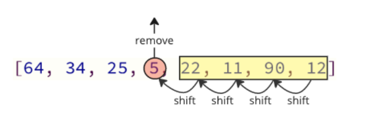

Operasi pergeseran ini memakan banyak waktu, dan kita bahkan belum selesai! Setelah nilai terendah (5) ditemukan dan dihapus, nilai tersebut dimasukkan di awal array, menyebabkan semua nilai berikutnya bergeser satu posisi ke atas untuk memberi ruang bagi nilai baru, seperti yang ditunjukkan pada gambar di bawah ini.

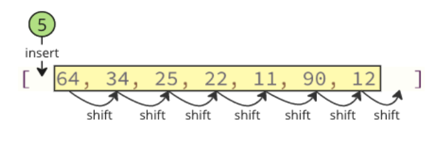

**Catatan:** Anda tidak akan melihat operasi pergeseran ini terjadi dalam kode jika Anda menggunakan bahasa pemrograman tingkat tinggi seperti Python atau Java, tetapi operasi pergeseran tetap terjadi di latar belakang. Operasi pergeseran tersebut membutuhkan waktu tambahan bagi komputer untuk melakukannya, yang dapat menjadi masalah.

#### Solusi: Tukar Nilai!

Alih-alih semua pergeseran, tukar nilai terendah (5) dengan nilai pertama (64) seperti di bawah ini.

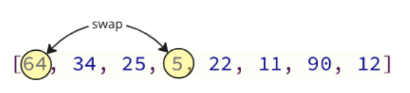

Kita dapat menukar nilai seperti yang ditunjukkan pada gambar di atas karena nilai terendah akan berada di posisi yang benar, dan tidak masalah di mana kita meletakkan nilai lain yang kita tukar, karena nilai tersebut belum diurutkan.

Berikut adalah implementasi dari Selection Sort yang disempurnakan, menggunakan pertukaran (swapping):

```python
my_array = [64, 34, 25, 12, 22, 11, 90, 5]

n = len(my_array)
for i in range(n):
    min_index = i
    for j in range(i+1, n):
        if my_array[j] < my_array[min_index]:
            min_index = j
    my_array[i], my_array[min_index] = my_array[min_index], my_array[i]

print("Sorted array:", my_array)
```

```
Sorted array: [5, 11, 12, 22, 25, 34, 64, 90]
```

### Soal - soal

1. Algoritma Bubble Sort standar akan terus berjalan membandingkan elemen hingga iterasi selesai, meskipun array sebenarnya sudah terurut di tengah proses. Tugas: Buatlah sebuah fungsi optimized_bubble_sort(arr) yang memodifikasi Bubble Sort standar. Tambahkan sebuah penanda (flag boolean) yang akan menghentikan perulangan (break) jika pada satu iterasi penuh tidak terjadi pertukaran (swap) sama sekali.

```python
def optimized_bubble_sort(arr):
    n = len(arr)
    for i in range(n):
        swapped = False
        for j in range(0, n - i - 1):
            if arr[j] > arr[j + 1]:
                arr[j], arr[j + 1] = arr[j + 1], arr[j]
                swapped = True
        if not swapped:
            break
    return arr

arr1 = [64, 34, 25, 12, 22, 11, 90]
hasil1 = optimized_bubble_sort(arr1)
print("Hasil Soal 1 (Bubble Sort):", hasil1)
```

```
Hasil Soal 1 (Bubble Sort): [11, 12, 22, 25, 34, 64, 90]
```

2. Biasanya algoritma Selection Sort mencari nilai minimum (terkecil) untuk ditaruh di awal array sehingga menghasilkan urutan ascending (naik). Tugas: Buatlah fungsi selection_sort_desc(arr). Ubahlah logika Selection Sort agar pada setiap iterasinya mencari nilai maksimum (terbesar) dan menaruhnya di depan, sehingga array hasil akhirnya terurut secara descending (turun).

```python
def selection_sort_desc(arr):
    n = len(arr)
    for i in range(n):
        max_idx = i
        for j in range(i + 1, n):
            if arr[j] > arr[max_idx]:
                max_idx = j
        arr[i], arr[max_idx] = arr[max_idx], arr[i]
    return arr

arr2 = [64, 34, 25, 12, 22, 11, 90]
hasil2 = selection_sort_desc(arr2)
print("Hasil Soal 2 (Selection Descending):", hasil2)
```

```
Hasil Soal 2 (Selection Descending): [90, 64, 34, 25, 22, 12, 11]
```

3. Insertion Sort sangat baik untuk menyisipkan data ke posisi yang tepat. Tugas: Diberikan sebuah list berisi kata-kata acak, misalnya ["apel", "semangka", "pisang", "jeruk", "kiwi"]. Buatlah fungsi insertion_sort_length(arr) menggunakan algoritma Insertion Sort untuk mengurutkan array tersebut berdasarkan panjang karakternya, dari kata yang paling pendek hingga kata yang paling panjang.

```python
def insertion_sort_length(arr):
    for i in range(1, len(arr)):
        key = arr[i]
        j = i - 1
        while j >= 0 and len(key) < len(arr[j]):
            arr[j + 1] = arr[j]
            j -= 1
        arr[j + 1] = key
    return arr

arr3 = ["apel", "semangka", "pisang", "jeruk", "kiwi"]
hasil3 = insertion_sort_length(arr3)
print("Hasil Soal 3 (Insertion Sort Panjang String):", hasil3)
```

```
Hasil Soal 3 (Insertion Sort Panjang String): ['apel', 'kiwi', 'jeruk', 'pisang', 'semangka']
```

4. Salah satu cara mengukur efisiensi algoritma sorting adalah dengan melihat berapa kali perpindahan data (swap) dilakukan. Tugas: Buatlah kode implementasi untuk Bubble Sort dan Selection Sort. Alih-alih hanya mengembalikan array yang sudah terurut, modifikasi kedua fungsi tersebut agar mengembalikan jumlah total pertukaran (swap) yang terjadi. Uji dengan array [64, 34, 25, 12, 22, 11, 90] dan bandingkan algoritma mana yang melakukan swap lebih sedikit.

```python
def bubble_sort_swaps(arr):
    n = len(arr)
    swaps = 0
    arr_copy = arr.copy()
    for i in range(n):
        for j in range(0, n - i - 1):
            if arr_copy[j] > arr_copy[j + 1]:
                arr_copy[j], arr_copy[j + 1] = arr_copy[j + 1], arr_copy[j]
                swaps += 1
    return swaps

def selection_sort_swaps(arr):
    n = len(arr)
    swaps = 0
    arr_copy = arr.copy()
    for i in range(n):
        min_idx = i
        for j in range(i + 1, n):
            if arr_copy[j] < arr_copy[min_idx]:
                min_idx = j
        if min_idx != i:
            arr_copy[i], arr_copy[min_idx] = arr_copy[min_idx], arr_copy[i]
            swaps += 1
    return swaps

arr4 = [64, 34, 25, 12, 22, 11, 90]
swap_bubble = bubble_sort_swaps(arr4)
swap_selection = selection_sort_swaps(arr4)
print("Hasil Soal 4 (Jumlah Swap Bubble):", swap_bubble)
print("Hasil Soal 4 (Jumlah Swap Selection):", swap_selection)
```

```
Hasil Soal 4 (Jumlah Swap Bubble): 14
Hasil Soal 4 (Jumlah Swap Selection): 4
```

5. Dalam dunia nyata, kita jarang mengurutkan sekumpulan angka tunggal, melainkan data yang lebih kompleks. Tugas: Diberikan list data siswa beserta nilainya: siswa = [{'nama': 'Budi', 'nilai': 85}, {'nama': 'Siti', 'nilai': 92}, {'nama': 'Andi', 'nilai': 78}, {'nama': 'Doni', 'nilai': 85}] Pilih salah satu dari ketiga algoritma (Bubble, Selection, atau Insertion Sort) dan tulis kodenya untuk mengurutkan list data siswa di atas berdasarkan nilai dari yang terendah ke tertinggi. (Catatan ekstra jika kamu ingin tantangan: Jika ada nilai yang sama, urutkan berdasarkan abjad nama mereka).

```python
def sort_siswa(arr):
    n = len(arr)
    for i in range(1, n):
        key = arr[i]
        j = i - 1
        while j >= 0 and (arr[j]['nilai'] > key['nilai'] or (arr[j]['nilai'] == key['nilai'] and arr[j]['nama'] > key['nama'])):
            arr[j + 1] = arr[j]
            j -= 1
        arr[j + 1] = key
    return arr

siswa = [
    {'nama': 'Budi', 'nilai': 85},
    {'nama': 'Siti', 'nilai': 92},
    {'nama': 'Andi', 'nilai': 78},
    {'nama': 'Doni', 'nilai': 85}
]
hasil5 = sort_siswa(siswa)
print("Hasil Soal 5 (Sort Dictionary):")
for s in hasil5:
    print(s)
```

```
Hasil Soal 5 (Sort Dictionary):
{'nama': 'Andi', 'nilai': 78}
{'nama': 'Budi', 'nilai': 85}
{'nama': 'Doni', 'nilai': 85}
{'nama': 'Siti', 'nilai': 92}
```